# Clase 2 - R web scraping

# Scrapear un sitio de noticias.

Vamos a buscar ahora crear un programa de scraping en un sitio de noticias y luego obtener las palabras más frecuentes. Primero cargamos las librerías necesarias.

```r
require(rvest)
require(tidyverse)
require(here)
require(openxlsx)
require(pander)
require(xml2)
require(RVerbalExpressions)
require(rapport)
```

```r
require(wordcloud2)
library(tidytext)
library(htmlwidgets)
require(openxlsx)
```

Luego, lo que buscaremos es realizar una búsqueda en la página. Utilizaremos el diario de pontevedra

```r
raiz <- "https://www.diariodepontevedra.es"
```

Si realizamos una búsqueda, veremos que la página tiene el siguiente formato: raiz + tags/palabras/ En nuestro caso elegimos buenos aires (recordar que las palabras deben estar separadas por “-”)

```r
busqueda <- paste0(raiz,"tags/" ,"buenos-aires")
```

Existe un nuevo inconveniente: No entran todas las noticias en una sola página. Por este motivo, debemos considerar la cantidad de páginas existentes. La estructura será la siguiente:

https://www.diariodepontevedra.es/tags/buenos-aires/?page=2

https://www.diariodepontevedra.es/tags/buenos-aires/?page=3

etc… Ahora que tenemos la estructura, vamos a buscar el rango de páginas necesario.

```r
pagina <- "https://www.diariodepontevedra.es/tags/buenos-aires"

lectura <- read_html(pagina)

#numeros <- lectura %>%
#  html_elements("div.text-center clearfix w-100 my-4")

max_pag <- lectura %>%
  html_nodes(".pagination a") %>%
  html_text()
  as.numeric() %>%
  max(na.rm = TRUE)
```

```
## [1] -Inf
```

```r
print(max_pag)
```

```
## [1] "Anterior"  "1"         "2"         "3"         "4"         "Siguiente"
```

```r
pagina_base <- "https://www.diariodepontevedra.es/tags/buenos-aires?page="

max_pag <- 1

repeat {

  pagina_actual <- paste0(pagina_base, max_pag)

  lectura <- tryCatch(read_html(pagina_actual),
                          error = function(e) NULL)

  if (is.null(lectura) || length(lectura %>%
                                 html_nodes(".pagination a") %>%
                                 html_text()
                                 %>%
                                 as.numeric()) == 0) {
    max_pag <- max_pag - 1  # Última página válida

    break
  }

  max_pag <- max_pag + 1
}
print(max_pag)
```

```
## [1] 4
```

Encontramos que el número máximo es 4. Por lo cual tendremos que entrar a 4 páginas con rango de 1 a 4 https://www.diariodepontevedra.es/tags/buenos-aires/?page=1 Busquemos los links en la página.

```r
paginas <- read_html("https://www.diariodepontevedra.es/tags/buenos-aires/?page=1") %>%
  html_elements("h2.title") %>%
  html_elements("a") %>%
  html_attr("href")

paginas
```

```
##  [1] "/articulo/gente/muere-liam-payne-ex-one-direction-caer-tercer-piso-buenos-aires/202410170753271324863.html"
##  [2] "/articulo/pontevedra/ambulantes-difundiran-suas-reivindicacions-todo-mundo/202308231027331267608.html"
##  [3] "/blog/ramon-rozas-ramonismo/dante-otra-orilla/202307251739271263938.html"
##  [4] "/video/videos/conductores-buenos-aires-sacan-guardarrail-evitar-atasco/202303011139171242401.html"
##  [5] "/video/videos/choco-carlos-bianchi-extecnico-multicampeon-boca-velez-colisiono-moto/202211072036351226034.html"
##  [6] "/video/videos/mujer-cae-debajo-tren-buenos-aires-sobrevive-danos-graves-afp/202204192011211196399.html"
##  [7] "/articulo/deporte-general/miles-personas-despiden-maradona-casa-rosada/202011261353131114671.html"
##  [8] "/articulo/pontevedra/cruzar-charco-sacar-dni/202001251246091070546.html"
##  [9] "/video/videos/panico-avion-volaba-miami-buenos-aires-fuertes-turbulencias/201810200017391005477.html"
## [10] "/articulo/cultura/inician-traslado-bos-aires-galicia-derradeira-leicion-do-mestre-castelao/201809252342411001946.html"
## [11] "/articulo/galicia/xunta-garante-preservara-patrimonio-do-centro-galego-buenos-aires/20180503123415978672.html"
## [12] "/articulo/sociedad/centro-gallego-buenos-aires-aplaza-decision-venta/20180425211714977405.html"
## [13] "/articulo/espana/rajoy-renuncia-caminatas-diarias-ni-buenos-aires/20180411212742975061.html"
## [14] "/articulo/mundo/centro-gallego-buenos-aires-afronta-posible-venta/20171219133755957130.html"
## [15] "/video/mundo/mas-80-heridos-48-detenidos-disturbios-registrados-buenos-aires/20171219014737957087.html"
```

Ahora que encontramos la manera de obtener los links por página, podemos realizar una iteración.

```r
links <- c()

for(i in 1:max_pag){

 paginas <- read_html(paste0("https://www.diariodepontevedra.es/tags/buenos-aires/?page=",i)) %>%
   html_elements("h2.title") %>%
   html_elements("a") %>%
   html_attr("href")

 links <- append(links, paginas)

}
print(links)
```

```
##  [1] "/articulo/gente/muere-liam-payne-ex-one-direction-caer-tercer-piso-buenos-aires/202410170753271324863.html"
##  [2] "/articulo/pontevedra/ambulantes-difundiran-suas-reivindicacions-todo-mundo/202308231027331267608.html"
##  [3] "/blog/ramon-rozas-ramonismo/dante-otra-orilla/202307251739271263938.html"
##  [4] "/video/videos/conductores-buenos-aires-sacan-guardarrail-evitar-atasco/202303011139171242401.html"
##  [5] "/video/videos/choco-carlos-bianchi-extecnico-multicampeon-boca-velez-colisiono-moto/202211072036351226034.html"
##  [6] "/video/videos/mujer-cae-debajo-tren-buenos-aires-sobrevive-danos-graves-afp/202204192011211196399.html"
##  [7] "/articulo/deporte-general/miles-personas-despiden-maradona-casa-rosada/202011261353131114671.html"
##  [8] "/articulo/pontevedra/cruzar-charco-sacar-dni/202001251246091070546.html"
##  [9] "/video/videos/panico-avion-volaba-miami-buenos-aires-fuertes-turbulencias/201810200017391005477.html"
## [10] "/articulo/cultura/inician-traslado-bos-aires-galicia-derradeira-leicion-do-mestre-castelao/201809252342411001946.html"
## [11] "/articulo/galicia/xunta-garante-preservara-patrimonio-do-centro-galego-buenos-aires/20180503123415978672.html"
## [12] "/articulo/sociedad/centro-gallego-buenos-aires-aplaza-decision-venta/20180425211714977405.html"
## [13] "/articulo/espana/rajoy-renuncia-caminatas-diarias-ni-buenos-aires/20180411212742975061.html"
## [14] "/articulo/mundo/centro-gallego-buenos-aires-afronta-posible-venta/20171219133755957130.html"
## [15] "/video/mundo/mas-80-heridos-48-detenidos-disturbios-registrados-buenos-aires/20171219014737957087.html"
```

[output cut: 35 more lines]

Le agregamos la raiz a los links.

```r
links_completos <- str_c(raiz, links)
links_completos
```

```
##  [1] "https://www.diariodepontevedra.es/articulo/gente/muere-liam-payne-ex-one-direction-caer-tercer-piso-buenos-aires/202410170753271324863.html"
##  [2] "https://www.diariodepontevedra.es/articulo/pontevedra/ambulantes-difundiran-suas-reivindicacions-todo-mundo/202308231027331267608.html"
##  [3] "https://www.diariodepontevedra.es/blog/ramon-rozas-ramonismo/dante-otra-orilla/202307251739271263938.html"
##  [4] "https://www.diariodepontevedra.es/video/videos/conductores-buenos-aires-sacan-guardarrail-evitar-atasco/202303011139171242401.html"
##  [5] "https://www.diariodepontevedra.es/video/videos/choco-carlos-bianchi-extecnico-multicampeon-boca-velez-colisiono-moto/202211072036351226034.html"
##  [6] "https://www.diariodepontevedra.es/video/videos/mujer-cae-debajo-tren-buenos-aires-sobrevive-danos-graves-afp/202204192011211196399.html"
##  [7] "https://www.diariodepontevedra.es/articulo/deporte-general/miles-personas-despiden-maradona-casa-rosada/202011261353131114671.html"
##  [8] "https://www.diariodepontevedra.es/articulo/pontevedra/cruzar-charco-sacar-dni/202001251246091070546.html"
##  [9] "https://www.diariodepontevedra.es/video/videos/panico-avion-volaba-miami-buenos-aires-fuertes-turbulencias/201810200017391005477.html"
## [10] "https://www.diariodepontevedra.es/articulo/cultura/inician-traslado-bos-aires-galicia-derradeira-leicion-do-mestre-castelao/201809252342411001946.html"
## [11] "https://www.diariodepontevedra.es/articulo/galicia/xunta-garante-preservara-patrimonio-do-centro-galego-buenos-aires/20180503123415978672.html"
## [12] "https://www.diariodepontevedra.es/articulo/sociedad/centro-gallego-buenos-aires-aplaza-decision-venta/20180425211714977405.html"
## [13] "https://www.diariodepontevedra.es/articulo/espana/rajoy-renuncia-caminatas-diarias-ni-buenos-aires/20180411212742975061.html"
## [14] "https://www.diariodepontevedra.es/articulo/mundo/centro-gallego-buenos-aires-afronta-posible-venta/20171219133755957130.html"
## [15] "https://www.diariodepontevedra.es/video/mundo/mas-80-heridos-48-detenidos-disturbios-registrados-buenos-aires/20171219014737957087.html"
```

[output cut: 35 more lines]

Ahora tenemos que realizar el mismo proceso que antes: Buscar la información que queremos y crear la tabla con nuestras noticias. Supongamos que queremos: titulo, resumen, autor, cuerpo del texto, link, fecha.

```r
noticia <-  read_html(links_completos[1])
```

## Titulo

```r
titulo <- noticia %>%
  html_element("h1.title") %>%
  html_text() %>%
  str_squish()
```

## Resumen

```r
resumen <-  noticia %>%
  html_element("div.summary") %>%
  html_text() %>%
  str_squish()
```

## Cuerpo del texto

```r
cuerpo <- noticia %>%
  html_elements("p") %>%
  html_text() %>%
  str_squish() %>%
  paste(collapse = '\"', "")

cuerpo <- gsub('\\"', "", cuerpo)
```

## Fecha

```r
fecha  <- noticia %>%
  html_element("span.content-meta-date-created") %>%
  html_text() %>%
  str_squish()
```

## Autor

```r
autor  <- noticia %>%
  html_element("span.author-name") %>%
  html_text() %>%
  str_squish()
```

## Creamos la función

```r
tabla_noticias <- function(links){


  noticia <- read_html(links)

  titulo <- noticia %>%
    html_element("h1.title") %>%
    html_text() %>%
    str_squish()

  resumen <-  noticia %>%
    html_element("div.summary") %>%
    html_text() %>%
    str_squish()

  cuerpo <- noticia %>%
    html_elements("p") %>%
    html_text() %>%
    str_squish() %>%
    paste(collapse = '\"', "")

  cuerpo <- gsub('\\"', "", cuerpo)

  fecha  <- noticia %>%
    html_element("span.content-meta-date-created") %>%
    html_text() %>%
    str_squish()

  autor  <- noticia %>%
    html_element("span.author-name") %>%
    html_text() %>%
    str_squish()

  tabla_final <- as.data.frame(cbind("titulo"=titulo, "autor" = autor, "resumen"=resumen,  "cuerpo"=cuerpo,
                                     "fecha" = fecha
                                     ))

  return(tabla_final)

}
```

```r
noticias <- tibble(
                titulo=character(),
                resumen=character(),
                cuerpo=character(),
                fecha=character(),
                autor= character()
                )

for(i in 1:length(links_completos)){

  resultado <- tabla_noticias(links_completos[i])

  noticias <- noticias %>%
    bind_rows(resultado)

}


print(noticias)
```

```
## # A tibble: 50 × 5
##    titulo                                             resumen cuerpo fecha autor
##    <chr>                                              <chr>   <chr>  <chr> <chr>
##  1 "Muere Liam Payne, ex de One Direction, tras caer… "El ca… "Liam… 17/o… "Ros…
##  2 "Os ambulantes difundirán as súas reivindicacións… "AGAA … "O lo… 23/a… "Red…
##  3 "Dante en la otra orilla"                          "El as… "Hast… 25/j… "Ram…
##  4 "Varios conductores sacan un guardarraíl para evi…  <NA>   "Lepa… 01/m… ""
##  5 "El extécnico del Atlético Carlos Bianchi sufre u…  <NA>   "Lepa… 07/n… ""
##  6 "Sobrevive tras perder el conocimiento y caer a l…  <NA>   "Ocur… 19/a… ""
##  7 "Miles de personas despiden a Maradona en la Casa… "El fé… "La c… 26/n… "Alb…
##  8 "Cruzar el charco para sacar el DNI en Pontevedra" "Maris… "Nunc… 25/e… "Jos…
##  9 "Pánico en un avión que volaba de Miami a Buenos …  <NA>   "Un a… 20/o… ""
## 10 "Inician o traslado de Bos Aires a Galicia de 'A … "A pez… "A pe… 25/s… "Alb…
## # ℹ 40 more rows
```

## Podemos crear una nube de palabras sencilla a partir de la columna cuerpo

```r
nube <- function(tabla){

  tabla_2 <- tabla %>%
    select(cuerpo)

  tabla_2 <- tabla_2 %>%
    mutate(txt = str_to_lower(cuerpo))

  tabla_2$cuerpo <- gsub("\\.\\(function\\(.*?\\)\\);", "", tabla_2$cuerpo)

  webs <- rx() %>%
      rx_find('http')%>%
      rx_anything_but(value = ' ')

  tabla_2$cuerpo <- gsub(webs, "", tabla_2$cuerpo)



  tabla_2 <- tabla_2 %>%
    mutate(txt = str_replace_all(txt, "[[:digit:]]", '')) %>%
    select(-1)



  stop_words <- as.data.frame(readLines("./data/stopwords.txt", encoding = "utf-8")) %>%
    rename(word= 1)

  unigram <- tabla_2 %>%
    unnest_tokens(output = word, input= txt, token = "ngrams", n=1) %>%
    na.omit() %>%
    anti_join(stop_words)

  nube_f <- unigram %>%
    count(word, sort =TRUE)

  return(nube_f)

}

nube <-  nube(noticias)
wordcloud2(nube)
```

[interactive chart not shown]

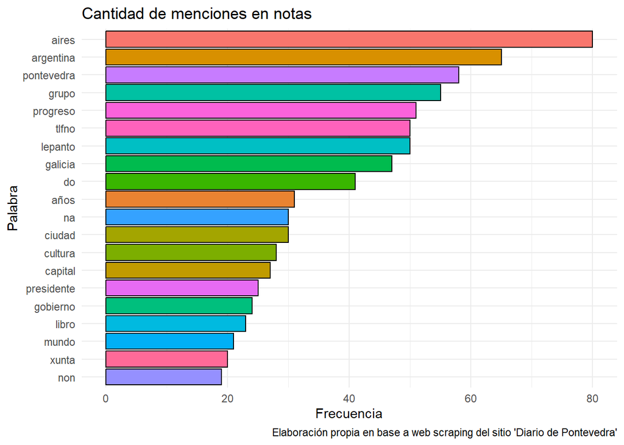

```r
grafico <- function(tabla){

ggplot(tabla[1:20,], aes(x=reorder(word,n), y=n))+
  geom_col(aes(fill=word),col="black")+
  coord_flip()+
  labs(title = paste("Cantidad de menciones en notas"),
       x="Palabra", y= "Frecuencia",
       caption="Elaboración propia en base a web scraping del sitio 'Diario de Pontevedra'")+
  theme_minimal()+
    theme(legend.position = "none")

}

grafico(nube)
```

Si queremos continuar la automatización, al conocer la estructura de búsqueda, podemos pedir una palabra por consulta y construir el link.

```r
palabra <- readline("Ingrese la/s palabra/s clave/s: ")


if(length(palabra > 1)){

palabra <- gsub(" ", "-", palabra)

}

raiz <- "https://www.diariodepontevedra.es"

busqueda <- paste0(raiz,"/tags/" ,palabra)

lectura <- read_html(busqueda)

max_pag <- lectura %>%
  html_nodes(".pagination a") %>%
  html_text() %>%
  as.numeric() %>%
  max(na.rm = TRUE)

print(max_pag)
```

```r
buscar_links <- c()

for( i in 1:max_pag){

recolectar_links <- paste0(busqueda, "?page=",i)

paginas <- read_html(recolectar_links) %>%
  html_elements("h2.title") %>%
  html_elements("a") %>%
  html_attr("href")

paginas_completas <- str_c(raiz, paginas)

buscar_links <- append(buscar_links, paginas_completas)

}
```

```r
print(buscar_links)
```

Convertir en función:

```r
obtener_links <- function(){

  palabra <<- readline("Ingrese la/s palabra/s clave/s: ")

  if(length(palabra > 1)){

    palabra <- gsub(" ", "-", palabra)

  }

  raiz <- "https://www.diariodepontevedra.es"

  busqueda <- paste0(raiz,"/tags/" ,palabra)

  #lectura <- read_html(busqueda)
 #  Busca la pagina más alta
  max_pag <- 1

  repeat {

    pagina_actual <- paste0(busqueda,"?page=", max_pag)

    #pagina_base <- "https://www.diariodepontevedra.es/tags/buenos-aires?page="

    lectura <- tryCatch(read_html(pagina_actual),
                            error = function(e) NULL)

    if (is.null(lectura) || length(lectura %>%
                                   html_nodes(".pagination a") %>%
                                   html_text()
                                   %>%
                                   as.numeric()) == 0) {
      max_pag <- max_pag - 1  # Última página válida

      break
    }

    max_pag <<- max_pag + 1
  }

##


  buscar_links <- c()

  for( i in 1:max_pag){

    recolectar_links <- paste0(busqueda, "?page=",i)

    paginas <- read_html(recolectar_links) %>%
      html_elements("h2.title") %>%
      html_elements("a") %>%
      html_attr("href")

    paginas_completas <- str_c(raiz, paginas)

    buscar_links <- append(buscar_links, paginas_completas)
  }

  return(buscar_links)

}
```

Probamos:

```r
links_nuevos <- obtener_links()

print(links_nuevos)
```

```r
noticias <- tibble(
                titulo=character(),
                resumen=character(),
                cuerpo=character(),
                fecha=character(),
                autor= character()
                )

for(i in 1:length(links_nuevos)){

  print(paste("Procesando noticia: ", i))

  resultado <- tabla_noticias(links_nuevos[i])

  noticias <- noticias %>%
    bind_rows(resultado)

}
```

## TD-IDF

```r
noticias_barcelona <- readRDS("./noticias_barcelona.RDS")

palabraS_noticias <- noticias_barcelona %>%
  mutate(entry_number = row_number()) %>%
        unnest_tokens(output = word,
                      input = cuerpo) %>%
        group_by(autor, word) %>%
        summarise(n = n()) %>%
        arrange(desc(n)) %>%
        ungroup()
```

```r
noticias_tf_idf <- palabraS_noticias %>%
  bind_tf_idf(word,autor , n)
```

La frecuencia inversa del documento (y por tanto tf-idf) es muy baja (cercana a cero) para las palabras que aparecen en muchos de los documentos de una colección; así es como este enfoque reduce el peso de las palabras comunes. La idf será un número mayor para las palabras que aparecen en una menor cantidad de documentos de la colección.

Ordenemos la tabla de forma diferente para identificar las palabras más importantes:

```r
noticias_tf_idf %>%
  arrange(desc(tf_idf))
```

```
## # A tibble: 34,637 × 6
##    autor                    word            n     tf   idf tf_idf
##    <chr>                    <chr>       <int>  <dbl> <dbl>  <dbl>
##  1 Jorge de Vivero          cosmopolita     2 0.0172  3.30 0.0568
##  2 Jorge de Vivero          culta           2 0.0172  3.30 0.0568
##  3 Jorge de Vivero          elegiría        2 0.0172  3.30 0.0568
##  4 Juan Antonio Pinto Antón os             18 0.0390  1.22 0.0475
##  5 Jorge de Vivero          duda            2 0.0172  2.60 0.0449
##  6 Jorge de Vivero          europeísta      2 0.0172  2.60 0.0449
##  7 Xaime Nogueira Casás     dous            7 0.0131  2.60 0.0341
##  8 VÃctor MÃ©ndez           n              11 0.0201  1.69 0.0340
##  9 Marta Rivera de la Cruz  valls           6 0.0175  1.91 0.0335
## 10 VÃctor MÃ©ndez           ã               7 0.0128  2.60 0.0334
## # ℹ 34,627 more rows
```

```r
unique(noticias_madrid$autor)
```

```r
jorge <- noticias_tf_idf %>%
  filter(autor == "Jorge de Vivero") %>%
  arrange(-tf_idf)
jorge
```

```
## # A tibble: 77 × 6
##    autor           word            n      tf   idf tf_idf
##    <chr>           <chr>       <int>   <dbl> <dbl>  <dbl>
##  1 Jorge de Vivero cosmopolita     2 0.0172   3.30 0.0568
##  2 Jorge de Vivero culta           2 0.0172   3.30 0.0568
##  3 Jorge de Vivero elegiría        2 0.0172   3.30 0.0568
##  4 Jorge de Vivero duda            2 0.0172   2.60 0.0449
##  5 Jorge de Vivero europeísta      2 0.0172   2.60 0.0449
##  6 Jorge de Vivero quién           2 0.0172   1.91 0.0329
##  7 Jorge de Vivero valls           2 0.0172   1.91 0.0329
##  8 Jorge de Vivero manuel          2 0.0172   1.69 0.0291
##  9 Jorge de Vivero concretarse     1 0.00862  3.30 0.0284
## 10 Jorge de Vivero currículum      1 0.00862  3.30 0.0284
## # ℹ 67 more rows
```

```r
jose <- noticias_tf_idf %>%
  filter(autor == "José Castro López")  %>%
  arrange(-tf_idf)
jose
```

```
## # A tibble: 232 × 6
##    autor             word              n      tf   idf tf_idf
##    <chr>             <chr>         <int>   <dbl> <dbl>  <dbl>
##  1 José Castro López cirujanos         5 0.0111   2.60 0.0289
##  2 José Castro López conocimientos     3 0.00667  3.30 0.0220
##  3 José Castro López lacy              3 0.00667  3.30 0.0220
##  4 José Castro López 5g                4 0.00889  2.20 0.0195
##  5 José Castro López tecnología        4 0.00889  2.20 0.0195
##  6 José Castro López doctor            3 0.00667  2.60 0.0174
##  7 José Castro López hospitales        3 0.00667  2.20 0.0146
##  8 José Castro López ais               2 0.00444  3.30 0.0146
##  9 José Castro López aporten           2 0.00444  3.30 0.0146
## 10 José Castro López channel           2 0.00444  3.30 0.0146
## # ℹ 222 more rows
```